# The BRIMMEST test: exact certification of reported means and standard deviations on bounded scales

Author

Affiliation

Ian Hussey

University of Bern

Abstract

Error-detection tests for reported summary statistics, including GRIM, GRIMMER, and the standard-deviation bounds tests, are necessary conditions: failing one proves a reported (mean, SD, n) is impossible, but passing all of them proves nothing. A residual set of reports clears every such screen and still corresponds to no possible dataset. We introduce BRIMMEST, an exact certification test for reported means and standard deviations on bounded integer scales. It enumerates the complete attainable (mean, SD) lattice for a design by dynamic programming over reachable (sum, sum of squares) states, rounds that lattice to the reporting precision, and tests membership. A hit proves that some real sample produces exactly the reported values; a miss proves that none does, relative to the admitted rounding conventions. The verdict is therefore exact in both directions, which no test in the GRIM family achieves. BRIMMEST agrees with brute-force enumeration and with the CLOSURE reconstruction algorithm on every case tested (zero disagreements across roughly 5,700 grid cells), while running two to three orders of magnitude faster than reconstruction, because its cost depends only on the scale limits and sample size rather than on how many datasets exist. Sweeping 556,975 reportable tuples across 13 designs, we quantify the blind spot of the closed-form screens and show it is not monotone in sample size. We also report implementation errors that the exact oracle exposed in widely used software, in both error directions. We situate BRIMMEST relative to CLOSURE and SPRITE, and recommend a three-stage workflow: closed-form screens first, BRIMMEST to settle survivors, and reconstruction only when the candidate datasets themselves are needed. The test is implemented as brimmest() in the strait R package.

# Introduction: necessary is not sufficient

A reported mean, standard deviation, and sample size are not free to take any values. When the underlying data are integers on a bounded scale, as with Likert-type items, counts, and most questionnaire measures, the reported statistics must be producible by some sample of $n$ integers between the scale limits, after rounding to the reported precision. Tests that exploit this fact have become standard tools of error detection. GRIM checks that the reported mean is a multiple of $1/n$ at the reported precision (Brown & Heathers, 2017). GRIMMER extends the logic to the standard deviation (Anaya, 2016). The SD-bounds tests check the reported SD against closed-form minimum and maximum bounds given the scale limits, $n$, and the mean (Hussey et al., in prep).

Each of these is a necessary condition. Failing one proves the report impossible. Passing all of them proves nothing, because none of them asks whether the mean and SD are *jointly* attainable by a single sample. In practice, a report that clears every screen is routinely described as “consistent”, a word that quietly overstates what was shown.

The gap is not hypothetical. On a 1–5 scale with $n = 9$, reporting to one decimal place, the pair mean $= 1.3$, SD $= 0.9$ lies inside the SD bounds, passes GRIM, and passes GRIMMER. No sample of nine integers between 1 and 5 produces it:

```r
brimmest(l = 1, u = 5, n = 9, mean = 1.3, sd = 0.9, digits = 1)
```

```
#>   mean  sd possible rules
#> 1  1.3 0.9    FALSE
```

This paper introduces the test that settles such cases. BRIMMEST (Bounds-Related Inconsistency of Means and Errors, Settled Test) is an exact certification procedure for reported (mean, SD) pairs on bounded integer scales, implemented as `brimmest()` in the strait R package. It enumerates the complete attainable (mean, SD) lattice for the design by dynamic programming, rounds the lattice to the reporting precision, and tests whether the reported pair is a member. A hit proves possibility: some sample rounds to exactly this report. A miss proves impossibility, relative to the rounding conventions admitted. The verdict is exact in both directions, which is precisely what the GRIM family cannot offer.

The name completes a series. GRIM and GRIMMER test granularity; brim and brimmer, their bounds-based counterparts in strait, test magnitude. All four are necessary conditions of increasing strength. BRIMMEST is superlative in the grammatical sense and, within its scope, in the technical one: no stronger test of the same question exists, because the question is decided. It is worth being clear at the outset that this makes it a different kind of test rather than a stronger member of the same family. The others are closed-form inequalities evaluated in constant time; BRIMMEST is a decision procedure with a computational cost, albeit a modest one.

The paper proceeds as follows. Section 2 measures the blind spot of the closed-form screens, since the case for an exact test rests on the residual it removes. Section 3 presents the algorithm. Section 4 reports its verification against brute-force enumeration and against CLOSURE. Section 5 develops the asymmetry between the two directions of the certificate, which governs how the test must be used in practice. Section 6 positions BRIMMEST against CLOSURE and SPRITE. Sections 7 to 9 cover practical usage, implementation errors the exact oracle exposed in existing software, and the limits of the method’s scope. Section 10 concludes.

# How big is the blind spot?

If the closed-form screens missed nothing, an exact test would be redundant. We measured the residual two ways.

## Grid-wise: every reportable tuple of a design

For a given design (scale limits, $n$, reported decimal places), the reportable (mean, SD) pairs form a finite grid, the umbrella of feasible cells under the SD bounds. `umbrella_data()` applies the full closed-form screen to every cell: the mean must lie in $[l, u]$ and pass rounding-aware GRIM, and the SD’s rounding interval must intersect the closed-form bounds and pass GRIMMER. Certifying the same cells with `brimmest()` then splits the screen-passers into the truly possible and the blind spot.

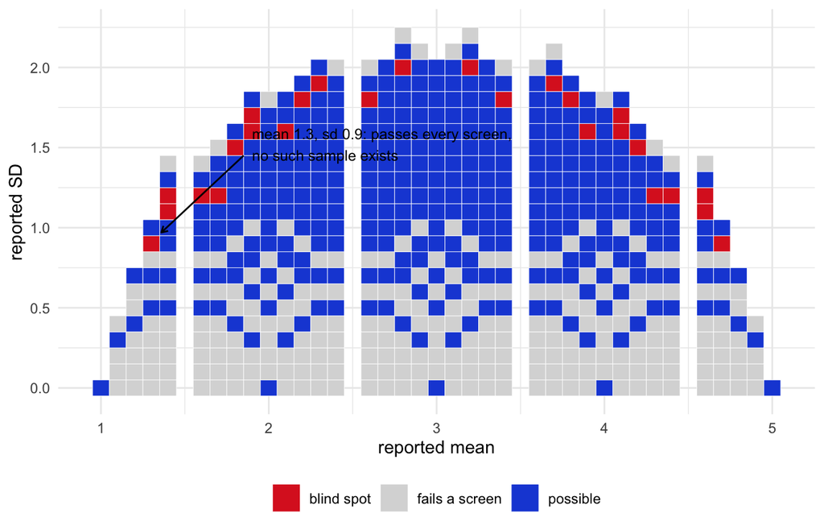

Figure 1: The blind spot of the closed-form screens. Every reportable (mean, SD) cell for a 1–5 scale, n = 9, one decimal place. Grey cells fail at least one closed-form test (bounds, GRIM, or GRIMMER). Blue cells pass the screens and are certified possible. Red cells pass every closed-form screen and are certified impossible: no sample of nine integers on 1–5 rounds to them. The annotated cell is the example from the introduction.

```r
um <- umbrella_data(n = 9, l = 1, u = 5, digits = 1, Z = "integer")
cert <- brimmest(l = 1, u = 5, n = 9, mean = um$mean, sd = um$sd, digits = 1)

um$status <- ifelse(!um$consistent, "fails a screen",
             ifelse(cert$possible, "possible", "blind spot"))

ggplot(um, aes(mean, sd, fill = status)) +
  geom_tile(width = 0.1, height = 0.1, colour = "white", linewidth = 0.15) +
  scale_fill_manual(values = c("fails a screen" = "grey85",
                               "possible" = "#1d4ed8",
                               "blind spot" = "#dc2626")) +
  annotate("segment", x = 1.85, y = 1.45, xend = 1.36, yend = 0.97,
           arrow = arrow(length = unit(0.15, "cm"))) +
  annotate("text", x = 1.9, y = 1.52, hjust = 0, size = 3.2,
           label = "mean 1.3, sd 0.9: passes every screen,\nno such sample exists") +
  labs(x = "reported mean", y = "reported SD", fill = NULL) +
  theme_minimal() +
  theme(legend.position = "bottom")
```

```r
c(cells            = nrow(um),
  passes_screen    = sum(um$consistent),
  certified        = sum(cert$possible),
  blind_spot       = sum(um$consistent & !cert$possible),
  wrongly_screened = sum(!um$consistent & cert$possible))
```

```
#>            cells    passes_screen        certified       blind_spot
#>              610              359              333               26
#> wrongly_screened
#>                0
```

Two numbers matter. The blind spot count is the price of using closed forms: reports the screen lets through that are nonetheless impossible. The `wrongly_screened` count is zero, here and everywhere we have looked: the closed-form screens never reject a report that real data can produce. The screens are safe; they are merely incomplete.

At scale, the same comparison was run across 13 designs spanning 1–5, 1–7, and 0–6 scales, $n$ from 8 to 30, at one and two reported decimal places: 556,975 reportable tuples in all. The bounds produced no false flags in any of them, and 758 blind-spot cells. The full sweep, with per-design tables and the assertion framework that guards every number, is reported in the validation supplement (`validate_brimmer_against_brimmest.qmd` in the strait repository); this article does not re-run it.

## The blind spot is not monotone in n

It is tempting to assume the residual vanishes with sample size. It does not, and it does not even shrink monotonically. On a 1–5 scale at two decimal places, the share of screen-passing cells that certify impossible was measured at 9.0% ($n = 10$), 4.8% ($n = 20$), 6.7% ($n = 40$), and 1.8% ($n = 80$).

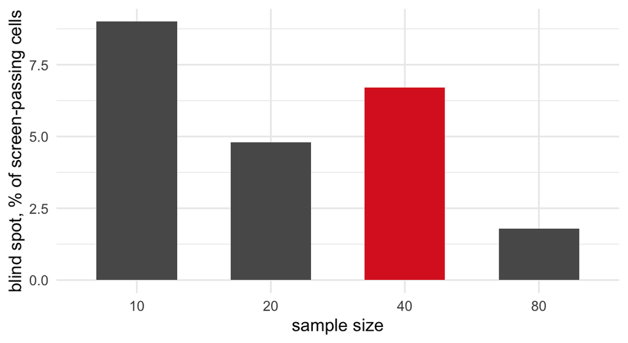

Figure 2: Blind-spot share of screen-passing cells, 1–5 scale, two decimal places, as measured in the validation supplement against the scrutiny build current at the time (see section 8). The non-monotonicity is real: the spike at n = 40 is the fingerprint of a floating-point boundary error in the screening software (scrutiny issue #86), which produces additional GRIMMER errors when n is a multiple of 40 at two decimal places. Larger samples do not obviate exact certification.

```r
prev <- data.frame(n = factor(c(10, 20, 40, 80)),
                   pct = c(9.0, 4.8, 6.7, 1.8))
ggplot(prev, aes(n, pct)) +
  geom_col(fill = c("grey35", "grey35", "#dc2626", "grey35"), width = 0.6) +
  labs(x = "sample size", y = "blind spot, % of screen-passing cells") +
  theme_minimal()
```

Two forces are at work. The genuine, method-level blind spot shrinks as the lattice of attainable pairs densifies with $n$. Implementation errors in the screening software do not shrink with it, and at particular sample sizes they dominate (section 8). Both are reasons to certify rather than assume.

## Within GRIMMER’s band: the missing achievability check

A second measurement isolates the method-level gap in GRIMMER itself, as distinct from the software that implements it. Within the band of SDs that GRIMMER can discriminate at all, the share of GRIMMER-consistent verdicts that are provably impossible grows from roughly 4% at $n = 10$ to roughly 97% at $n = 1000$, and does so identically in two independent implementations (scrutiny and rsprite2), so the gap belongs to the published method rather than to either codebase.

The gap has a closed form. Writing the integer sample sum as $s = nm + r$ with $0 \le r < n$, an integer sample with sum $s$ has sum of squares at least

$$q_{\min}(s, n) = n m^2 + 2 m r + r,$$

attained by the two-point sample with $n - r$ observations at $m$ and $r$ at $m + 1$. Equivalently, the sample SD has the granularity floor $s_{\min} = \sqrt{r(n-r)/(n(n-1))}$. GRIMMER as published tests the parity and granularity of the reconstructed sum of squares but never checks $q \ge q_{\min}(s, n)$, so it accepts sums of squares below the attainable floor. Adding the check makes GRIMMER exact for $n \ge 5$; samples of 2 to 4 retain gaps of the sums-of-few-squares kind that no closed form repairs. We note this repair because it is cheap and scale-free, and a repaired GRIMMER is a better first-line screen. It does not remove the need for certification: the repaired test is still necessary-only for $n < 5$, and it still checks the SD against the mean’s sum only through the reconstructed $q$, not against joint attainability on a bounded scale.

# The method

## The attainable lattice

Fix integer scale limits $l \le u$, sample size $n$, and (for multi-item composites) the number of items $k$. Shift and scale the data to $y_i = m_g (x_i - l) \in \{0, 1, \dots, W\}$, where $W = m_g (u - l)$ and $m_g = k$ for mean-scored composites and $1$ otherwise. Every sample statistic we need is a function of the pair

$$(S, Q) = \Big( \sum_i y_i, \; \sum_i y_i^2 \Big),$$

with mean $= l + S / (n m_g)$ and SD $= \sqrt{(Q - S^2/n) / (n-1)} \, / \, m_g$. Two samples with the same $(S, Q)$ are indistinguishable to a (mean, SD) report, so the object to enumerate is not the sample space but the set of reachable $(S, Q)$ states.

That set obeys a recurrence: the states reachable with $t$ observations are the states reachable with $t - 1$, each extended by one more value $y \in \{0, \dots, W\}$, which adds $y$ to $S$ and $y^2$ to $Q$. Dynamic programming over this recurrence, $n$ steps of a boolean table, enumerates the exact attainable lattice. No sample is ever constructed and no distributional information survives; the lattice records which pairs are reachable, not how.

## Making it fast

The naive table over $(S, Q)$ has $nW \times nW^2$ cells and is wasteful in ways that compound. The strait implementation applies five reductions, all in plain R, which together speed the enumeration by a factor of 23 to 29:

1. **A better second axis.** Replace $Q$ by $R = WS - Q = \sum_i y_i (W - y_i)$. Each observation contributes at most $\lfloor W^2/4 \rfloor$ to $R$, against $W^2$ to $Q$, so the axis is four times shorter, and $R \ge 0$ always.
2. **Common divisor.** The per-value contributions $y(W - y)$ share a greatest common divisor $g$ ($g = 2$ whenever $W$ is odd); dividing the axis by $g$ halves it again in the common case.
3. **Growing window.** After $t$ observations only $tW + 1$ values of $S$ are reachable, so early steps operate on a small corner of the table rather than all of it.
4. **Reflection.** The substitution $y \to W - y$ maps $S \to tW - S$ and leaves $R$ fixed, so the table is symmetric; compute the lower half of the $S$ axis and mirror it.
5. **Byte storage.** One-byte `raw` cells rather than four-byte logicals keep the working set in cache.

One implementation lesson is worth recording because it inverts the usual advice. Dense whole-table operations were six times slower than a sparse scatter of reachable states, because reachable cells are only about 7% of the naive grid; vectorised block operations only begin to win after reductions 1 to 4 shrink the table around the occupied region. Measured end to end, a 1–7 scale at $n = 61$ fell from 2.57 s to 0.098 s. The lattice reaches $n = 300$ on a 0–6 scale (1.57 million attainable pairs) in about 11 s and $n = 400$ on 1–7 (2.8 million pairs) in about 23 s, well past the point where reconstruction-based methods are uncomfortable. A guard (`max_cells`, default $2 \times 10^7$) makes the enumeration fail cleanly rather than exhaust memory on designs beyond its reach, such as wide mean-scored composites at large $n$.

## Certifying one report without enumerating every other

The five reductions shrink the table but leave the work proportional to the whole design. For a single report that is a membership question answered by a reachability-of-everything computation, and past a certain scale width the guard refuses outright: a 0–63 inventory at $n = 50$ would need a $3151 \times 24801$ table. Yet a report pins both coordinates almost completely.

The mean’s rounding interval admits only integer sums $S \in [n(m_{\text{lo}} - l),\, n(m_{\text{hi}} - l)]$ — typically one to five values rather than thousands. This is the GRIM condition, read as a constraint that generates candidates rather than as a test that rejects. Each candidate $S$ then pins the sum of squares to a narrow window, because $Q = S^2/n + (n-1)\,s^2$ and $s$ is known to its reporting precision. The question becomes: can $n$ integers in $[0, W]$ realise one of a handful of $(S, Q\text{-window})$ targets? Three consequences follow.

**Inverse rounding.** The reported values are unrounded to intervals once, rather than the lattice being forward-rounded cell by cell under every admitted rule.

**A corridor rather than a rectangle.** A partial sum $s$ after $t$ observations is viable only if the remaining $k = n - t$ can still carry it to some target, giving $s \in [S^\ast - kW,\, \min(tW, S^\ast)]$, and likewise $R \in [R^\ast_{\min} - k\lfloor W^2/4\rfloor / g,\, R^\ast_{\max}]$. States outside are never allocated, let alone visited.

**Early exit in one direction.** An observation with $y = 0$ contributes nothing to either coordinate, so a target reached after $t < n$ observations pads out to exactly $n$ with scores at the scale minimum. Reachability is therefore monotone in $t$, and a hit can be declared the moment it appears. Possibility is often immediate; impossibility still requires sweeping the whole corridor. The asymmetry runs in the useful direction for screening, where most reports are real.

Measured, the corridor holds about 9% of the full table’s cells across the designs tested. The wall-clock gain is smaller than that ratio suggests — roughly a factor of two on large designs — because the per-layer windows forfeit the reflection symmetry of reduction 4 and add bookkeeping the dense sweep does not pay. The decisive gain is categorical rather than proportional: designs the lattice refuses become answerable at all. The 0–63 inventory at $n = 50$ certifies in about 105 s where the lattice route cannot run, and a 0–20 scale at $n = 30$ falls from 0.97 s to 0.44 s. Small designs keep the lattice route, which is cheaper there and is cached per $(l, u, n)$, so screening a table of reports on one design pays for the enumeration once.

The two routes are interchangeable by construction, and are verified to be so: their verdicts agree over 1.75 million reporting-grid cells spanning six designs, two reporting precisions and two rounding rules.

## Replacing the sweep with arithmetic and a witness

The corridor still sweeps. Its cost is set by the design, not by the report, which is what makes the scale width a barrier rather than an inconvenience. Two observations remove the sweep for almost every report.

**The sandwich.** At a fixed sum $S$, the achievable sums of squares lie between the clustered configuration and the Structure S one — the integer forms of the floor and ceiling the closed-form screens already compute:

$$q_{\min}(S) = (n - r)m^2 + r(m+1)^2, \quad m = \lfloor S/n \rfloor,\ r = S - nm$$
$$q_{\max}(S) = \nu W^2 + \rho^2, \quad \nu = \lfloor S/W \rfloor,\ \rho = S - \nu W$$

and every sample satisfies $Q \equiv S \pmod 2$, because $y^2 \equiv y \pmod 2$ term by term. A window that meets no integer of the sum’s parity inside $[q_{\min}, q_{\max}]$ is impossible on arithmetic alone, in $O(1)$ per candidate sum. The parity condition is not a refinement of the bounds: it rejects reports comfortably inside them, and it does so at a rate that does not vanish with $n$. On a 0–100 scale at $n = 100$, a mean of 99.80 with an SD of 0.50 is disposed of by parity, the sole integer its SD window admits being odd where the sum is even.

**The witness.** What survives the sandwich goes to a constructive search over the sample itself, ordered non-increasingly, which is to say over the partitions of $S$ into at most $n$ parts of size at most $W$. At every step the sandwich is re-applied to what remains to be placed, with the cap set by the value just chosen, and the children are tried in order of how centrally the surviving window sits inside each child’s own sandwich. Reaching a complete sample proves possibility and hands back a witness; exhausting the tree proves impossibility.

The search is depth-first on an explicit stack rather than recursive, so its depth — one level per observation placed — is not a constraint: a report at $n = 20000$ is certified, with a witness, in under half a second.

Two structural choices keep the tree small. Requiring the sequence to be non-increasing collapses the $n!$ orderings of a sample to one. Reflecting $y \mapsto W - y$ whenever $S$ sits above $nW/2$ — under which $S \mapsto nW - S$ and $Q \mapsto Q + nW^2 - 2WS$ — means the search always builds from the nearer wall, where the partition tree is shallow. Near either wall the surviving tree is a handful of nodes, which is precisely where the closed-form screens leak: the blind-spot cell of the introduction has one candidate sum and three reachable values of $Q$, so the certificate costs three configurations rather than a corridor sweep.

This subsumes the enumeration of the ceiling’s top rungs as a special case, and it is strictly more informative than a greedy construction would be: a greedy walk upward from the clustered configuration certifies possibility when it succeeds and concludes nothing when it fails, whereas an exhausted search is a proof in both directions.

What remains swept is a sliver: reports whose search neither completes nor exhausts within budget, for which the corridor still answers. No such report appeared in the validation sweep, but the fallback is retained because its absence there is a measurement, not a theorem.

## The analytic certificate, step by step

Both routes above still sweep a state space whose size is set by the design rather than by the report, which is why a guard is needed at all. The blind-spot geometry suggests this may be removable, and it is. This section develops the structure that removes it — the *spectrum* of attainable sums of squares at a fixed sum — one step at a time, each step carrying the picture that motivates the next. It ends with a certificate that is exact in both directions and sweeps nothing: no corridor, no node budget, no `max_cells` guard. It ships as `engine = "analytic"` in `brimmest()` and is now the default; the search and corridor machinery of the previous sections is retained verbatim as `engine = "search"`, and `engine = "both"` runs the two independent methods on every report and errors on any disagreement.

### Step 1: the spectrum at a fixed sum

Fix a candidate sum $S$ on the shifted scale $y = x - l \in [0, W]$. The sandwich says every attainable $Q = \sum y_i^2$ lies between the clustered floor $q_{\min}(S)$ and the Structure S ceiling $q_{\max}(S)$; parity says $Q \equiv S \pmod 2$. The question the closed forms cannot answer is which of the remaining integers are actually realised. Figure 3 answers it exhaustively for a small design, and the answer has a shape.

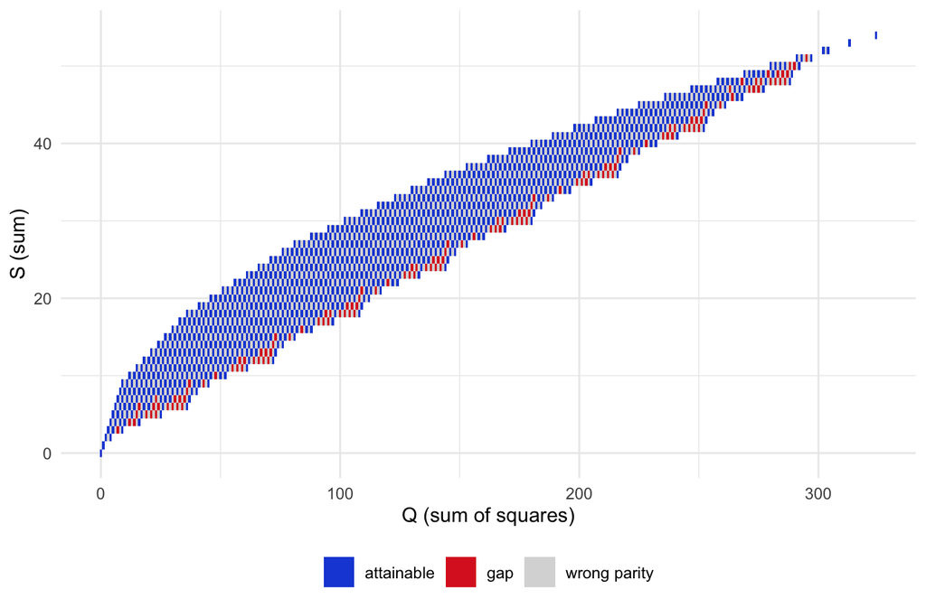

Figure 3: The spectrum of attainable sums of squares, mapped exhaustively for a 1–7 scale at n = 9 (shifted to 0–6). Each row is one candidate sum S; columns are the integers Q between the clustered floor and the Structure-S ceiling for that sum. Grey: wrong parity, excluded by arithmetic. Blue: attainable by some sample. Red: right parity, inside the sandwich, yet attainable by no sample — the gaps. Every gap hugs the ceiling; below a thin fringe the spectrum is contiguous. The point-symmetry is the reflection y -> W - y.

```r
# exact attainable (S, Q) states for n items on 0..W, by dynamic programming
ach_spectrum <- function(W, n) {
  S_max <- n * W; Q_max <- n * W^2
  cur <- matrix(FALSE, S_max + 1, Q_max + 1)
  cur[1, 1] <- TRUE
  for (i in seq_len(n)) {
    nxt <- matrix(FALSE, S_max + 1, Q_max + 1)
    for (v in 0:W) {
      ss <- 1:(S_max + 1 - v); qq <- 1:(Q_max + 1 - v^2)
      nxt[ss + v, qq + v^2] <- nxt[ss + v, qq + v^2] | cur[ss, qq]
    }
    cur <- nxt
  }
  cur
}
qmin_i <- function(S, n) { m <- S %/% n; r <- S - n * m; (n - r) * m^2 + r * (m + 1)^2 }
qmax_i <- function(S, W) { a <- S %/% W; b <- S - a * W; a * W^2 + b^2 }
# attainable sums of squares over the partitions of m into parts of size <= cap
corner_spectrum <- function(m, cap = m) {
  B <- vector("list", m + 1); B[[1]] <- 0L
  if (m >= 1 && cap >= 1) for (p in seq_len(min(cap, m))) for (s in p:m) {
    src <- B[[s - p + 1]]
    if (!is.null(src)) B[[s + 1]] <- union(B[[s + 1]], src + p^2)
  }
  sort(B[[m + 1]])
}

W <- 6; n_ex <- 9
A <- ach_spectrum(W, n_ex)
spec <- do.call(rbind, lapply(0:(n_ex * W), function(S) {
  Q <- qmin_i(S, n_ex):qmax_i(S, W)
  data.frame(S = S, Q = Q,
             status = ifelse((Q - S) %% 2 != 0, "wrong parity",
                             ifelse(A[S + 1, Q + 1], "attainable", "gap")))
}))
ggplot(spec, aes(Q, S, fill = status)) +
  geom_tile() +
  scale_fill_manual(NULL, values = c(attainable = "#1d4ed8", gap = "#dc2626",
                                     `wrong parity` = "grey85")) +
  labs(x = "Q (sum of squares)", y = "S (sum)") +
  theme_minimal() + theme(legend.position = "bottom")
```

Two facts, visible at a glance and verified exhaustively across every design we tested (all $W \le 8$, $n \le 12$ — 859,672 membership checks — plus wide-scale spot checks to $W = 517$): the gaps are confined to a thin fringe below the ceiling, and below that fringe every integer of the right parity is attainable. The fringe is where every blind-spot cell lives; the contiguous interior is why most reports are settled by arithmetic alone.

### Step 2: a report becomes a one-dimensional question

A reported (mean, SD) pins its candidate sums by GRIM and, at each sum, a window of admissible $Q$. Certification is then a one-dimensional question: does the window contain a member of the spectrum? Figure 4 walks the blind-spot cell of the introduction through it.

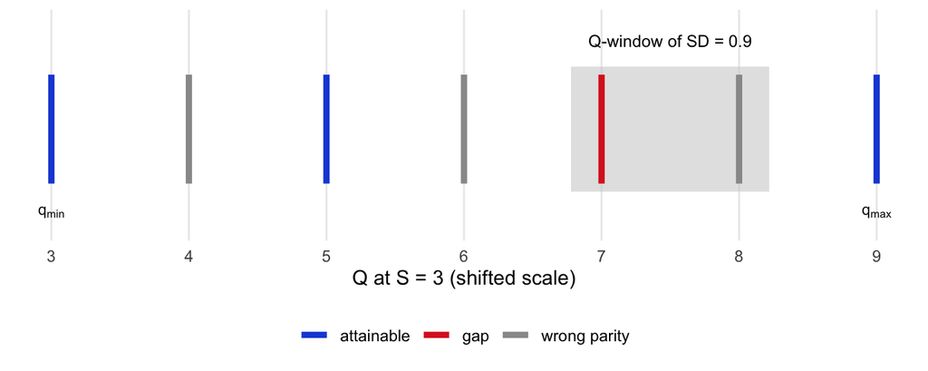

Figure 4: The blind-spot cell of the introduction, decided on one axis. Mean 1.3 on a 1–5 scale at n = 9 admits the single sum S = 12 (shifted: 3); SD 0.9 maps to the Q-window [6.78, 8.22]. The window contains two integers: 8 fails parity (S is odd), and 7 — inside the sandwich, right parity, the survivor every closed-form screen passes — falls in a gap: the partitions of 3 realise only Q = 3, 5, 9. Impossible, certified without touching a state space.

```r
S_bs <- 3; n_bs <- 9
att <- corner_spectrum(S_bs)                       # 3, 5, 9
q_lo <- (n_bs - 1) * 0.85^2 + S_bs^2 / n_bs
q_hi <- (n_bs - 1) * 0.95^2 + S_bs^2 / n_bs
ticks <- data.frame(Q = 3:9)
ticks$status <- ifelse((ticks$Q - S_bs) %% 2 != 0, "wrong parity",
                       ifelse(ticks$Q %in% att, "attainable", "gap"))
ggplot() +
  annotate("rect", xmin = q_lo, xmax = q_hi, ymin = 0.25, ymax = 1.05,
           fill = "grey80", alpha = .55) +
  geom_segment(data = ticks, aes(x = Q, xend = Q, y = 0.3, yend = 1,
                                 colour = status), linewidth = 1.6) +
  scale_colour_manual(NULL, values = c(attainable = "#1d4ed8", gap = "#dc2626",
                                       `wrong parity` = "grey60")) +
  annotate("text", x = (q_lo + q_hi) / 2, y = 1.22,
           label = "Q-window of SD = 0.9", size = 3.2) +
  annotate("text", x = 3, y = 0.12, label = "q[min]", parse = TRUE, size = 3) +
  annotate("text", x = 9, y = 0.12, label = "q[max]", parse = TRUE, size = 3) +
  scale_x_continuous(breaks = 3:9) +
  labs(x = "Q at S = 3 (shifted scale)", y = NULL) +
  coord_cartesian(ylim = c(0, 1.35)) +
  theme_minimal() +
  theme(axis.text.y = element_blank(), panel.grid.major.y = element_blank(),
        panel.grid.minor = element_blank(), legend.position = "bottom")
```

When the window reaches the contiguous interior, the verdict is immediate in the other direction: any integer of the right parity in the window is attainable, and the constructive search of the previous section produces its witness in $O(n)$. Everything that remains to explain is the fringe.

### Step 3: the move that generates the fringe

Write $S = aW + b$. The ceiling $q_{\max} = aW^2 + b^2$ is attained by the Structure S configuration alone: $a$ values at the ceiling, one remainder, the rest at the floor. Every other configuration is reached by *demoting* some number $j$ of ceiling values and re-partitioning the freed $jW + b$ units below the ceiling, and each such move pays a quantised price in $Q$ — the deficit $D = q_{\max} - Q$. Figure 5 shows the first rungs.

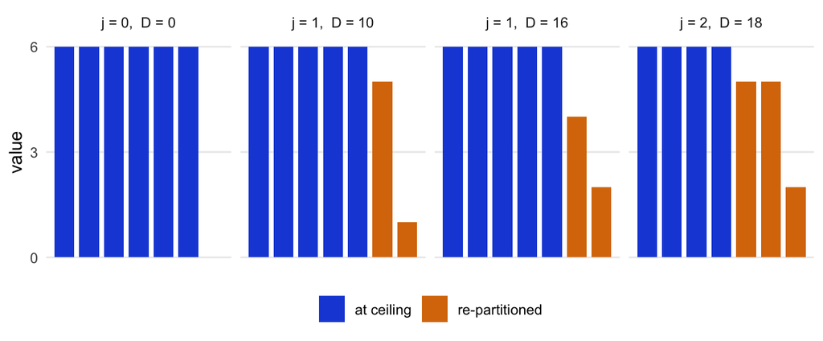

```r
cfgs <- list(list(j = 0, v = c(6, 6, 6, 6, 6, 6)),
             list(j = 1, v = c(6, 6, 6, 6, 6, 5, 1)),
             list(j = 1, v = c(6, 6, 6, 6, 6, 4, 2)),
             list(j = 2, v = c(6, 6, 6, 6, 5, 5, 2)))
demote <- do.call(rbind, lapply(cfgs, function(cf) {
  D <- 6 * 36 - sum(cf$v^2)
  data.frame(panel = sprintf("j = %d,  D = %d", cf$j, D),
             pos = seq_along(cf$v), y = cf$v,
             part = ifelse(cf$v == 6, "at ceiling", "re-partitioned"))
}))
ggplot(demote, aes(pos, y, fill = part)) +
  geom_col(width = .8) +
  facet_wrap(~panel, nrow = 1) +
  scale_fill_manual(NULL, values = c(`at ceiling` = "#1d4ed8",
                                     `re-partitioned` = "#d97706")) +
  scale_y_continuous(breaks = c(0, 3, 6)) +
  labs(x = NULL, y = "value") +
  theme_minimal() +
  theme(axis.text.x = element_blank(), panel.grid.major.x = element_blank(),
        panel.grid.minor = element_blank(), legend.position = "bottom")
```

The prices are quantised because a demoted unit trades a large square for small ones. That is the entire mechanism of the blind spot, and it has a pleasant classical face: $T = (Q - S)/2 = \sum \binom{y_i}{2}$ is a sum of triangular numbers, and by Gauss’s Eureka theorem every integer is a sum of three of them — so absent the bounds, every parity-consistent $Q$ would be attainable. Gaps exist only where the constraint $\sum p_i \le S$ forces the representation onto one huge triangular number, and huge triangular numbers are sparse.

### Step 4: bands, and where the gaps end

Grouping the configurations of the fringe by their largest part makes the gap structure exact. For the corner case ($S \le W$), the configurations with largest part $S - j$ occupy the band $[(S-j)^2 + j,\ (S-j)^2 + j^2]$: two parts at the top of a band, a part plus singletons at its bottom. Bands with small $j$ are disjoint — those separations are the gaps — and they merge into a continuum once $j^2 + 3j$ outgrows $2S$, i.e. around $j \approx \sqrt{2S}$. Below the last separation the spectrum is contiguous.

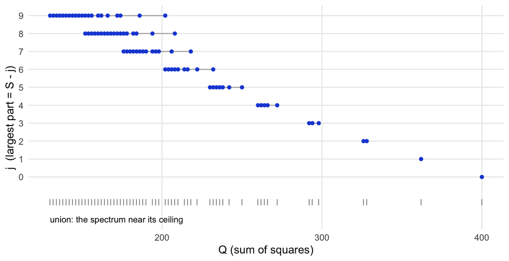

Figure 6: The fringe organised by largest part, for partitions of S = 20 (corner case). Row j holds the configurations whose largest part is 20 - j; segments span each band, points are its attainable values of Q. Bands with small j are separated — the white space between them is exactly the gap structure of the spectrum (union on the bottom rug) — and bands overlap into a continuum once j is of order the square root of 2S. Within each band the pattern is the spectrum of the partitions of j: the fringe is a self-similar copy of the whole problem at a smaller scale.

```r
S0 <- 20
bands <- do.call(rbind, lapply(0:9, function(j) {
  qs <- corner_spectrum(j, cap = S0 - j) + (S0 - j)^2
  data.frame(j = j, Q = qs)
}))
rug <- data.frame(Q = sort(unique(bands$Q)))
ggplot() +
  geom_segment(data = aggregate(Q ~ j, bands, range),
               aes(x = Q[, 1], xend = Q[, 2], y = j, yend = j),
               colour = "grey70", linewidth = .5) +
  geom_point(data = bands, aes(Q, j), colour = "#1d4ed8", size = 1.3) +
  geom_point(data = rug, aes(Q, -1.4), shape = "|", size = 2, colour = "grey30") +
  annotate("text", x = min(bands$Q), y = -2.35, hjust = 0, size = 3,
           label = "union: the spectrum near its ceiling") +
  scale_y_continuous(breaks = 0:9) +
  labs(x = "Q (sum of squares)", y = "j  (largest part = S - j)") +
  theme_minimal() + theme(panel.grid.minor = element_blank())
```

### Step 5: the fringe is design-local, and the certificate follows

The final structural fact is what makes the certificate cheap. Because the fringe is generated by demotions near the ceiling, its deficit pattern depends only on $(W, b)$ once $a \ge 2$: sums that differ by whole multiples of $W$ share it exactly. Figure 7 shows the pattern locking in.

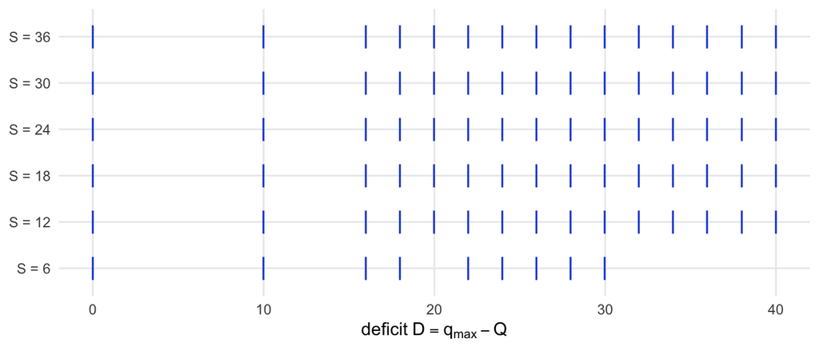

Figure 7: Attainable deficits D from the mean-conditional ceiling, 0–6 scale at n = 12, for sums that share b = 0 (S = 6, 12, …, 36, so a = 1, …, 6). Ticks mark attainable D; blank columns of even D are the gaps. From a = 2 on, the rows are identical: the fringe depends only on the scale width and the remainder b, not on the sum, the mean, or n. Certification in the fringe therefore costs the same for n = 12 as for n = 12,000, and the fringe is the only place where anything beyond arithmetic happens at all.

```r
A12 <- ach_spectrum(6, 12)
fr <- do.call(rbind, lapply(seq(6, 36, by = 6), function(S) {
  hi <- qmax_i(S, 6)
  D <- 0:min(40, hi - qmin_i(S, 12))
  keep <- (hi - D - S) %% 2 == 0
  data.frame(S = S, D = D[keep], att = A12[S + 1, hi - D[keep] + 1])
}))
ggplot(subset(fr, att), aes(D, factor(S, labels = paste0("S = ", seq(6, 36, 6))))) +
  geom_point(shape = "|", size = 5, colour = "#1d4ed8") +
  labs(x = expression(deficit ~ D == q[max] - Q), y = NULL) +
  theme_minimal() + theme(panel.grid.minor = element_blank())
```

Assembling the five steps gives the certificate. Clip the report’s window by the sandwich and parity ($O(1)$). If it reaches the contiguous interior, possible — with a witness from the constructive search. Otherwise the window lies in the fringe, and the demotion decomposition is recursed exactly: each level demotes ceiling values and asks the same question of a problem one cap smaller, terminating because the decomposition is complete. No state space is built, so nothing scales with the design: the 0–63 inventory at $n = 50$ that motivated the corridor certifies in well under a millisecond either way, and the `max_cells` guard is simply never consulted. Correctness does not rest on the contiguity of the interior — the decomposition is exhaustive regardless; contiguity is why the recursion is fast, not why it is right. Its verdicts agree with the search and lattice routes on every comparison run: roughly 1.5 million checks spanning brute force, both engines, scale widths to 517, sum-score designs, and one to three reported decimals, with `engine = "both"` repeating the cross-check on every user call that requests it. That standing cross-check has already paid its way: on its first extended run it exposed a floating-point boundary error in our own lattice route’s forward rounding under the directional rounding rules (an attainable mean of exactly $113/25 = 4.52$ scales to $451.99999999999994$, which truncation filed under 4.51), fixed in the same release.

What remains open is the contiguity *theorem*: a proof, with explicit constants, that the gaps are confined to a fringe of depth $O(S^{3/2})$ at the corners and $O(W^{3/2})$ in the interior, as every computation here finds. Its resolution would upgrade the interior shortcut from a validated observation to a guarantee, and it is the mathematical question this method poses.

## From lattice to verdict

The lattice holds exact statistics; reports are rounded. `brimmest()` rounds every lattice pair to the reported precision under each admitted rounding rule and tests whether the reported pair is a member of the rounded set. Matching is done in integer grid steps (a mean reported to 2 dp becomes a whole number of hundredths), which is exact and sidesteps floating-point comparison entirely. The verdict is returned per report, together with the rounding rules under which it is reachable:

```r
brimmest(l = 1, u = 5, n = 9, digits = 1,
         mean = c(3.0, 1.3, 2.5, 2.0),
         sd   = c(1.0, 0.9, 1.2, 1.1))
```

```
#>   mean  sd possible             rules
#> 1  3.0 1.0     TRUE half_up,half_down
#> 2  1.3 0.9    FALSE
#> 3  2.5 1.2    FALSE
#> 4  2.0 1.1     TRUE half_up,half_down
```

One lattice is built per design, cached, and reused across every report, so certifying a table of results costs barely more than certifying one. Where the design is large and the reports are few, the targeted route above is taken instead and the lattice is never built; the choice is automatic and the verdicts are identical either way.

## Why the closed forms leak

The lattice view also explains the blind spot geometrically. The closed-form bounds trace the smooth envelope of the attainable region; the attainable pairs are a discrete lattice strictly inside it. Near the mean-conditional ceiling the lattice thins, and reporting-grid cells fit between the envelope and the nearest lattice point: inside every closed-form bound, yet empty.

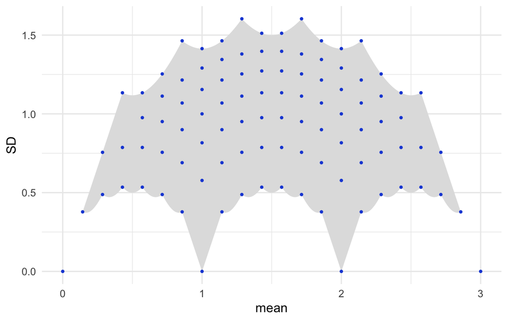

Figure 8: Why closed-form screens must leak. One 0–3 item, n = 7. Points are the complete attainable (mean, SD) lattice; the shaded band is the closed-form quasi-integer envelope that the bounds tests check against. Near the ceiling the lattice thins, and a reporting grid laid over this picture has cells that lie inside the band but contain no attainable point. Those cells are the blind spot.

```r
lat  <- sd_region_data(l = 0, u = 3, n = 7, rule = "attainable")
band <- sd_region_data(l = 0, u = 3, n = 7, rule = "quasi")

ggplot() +
  geom_ribbon(data = band, aes(x = mean, ymin = lo, ymax = hi),
              fill = "grey88") +
  geom_point(data = lat, aes(mean, sd), size = 0.7, colour = "#1d4ed8") +
  labs(x = "mean", y = "SD") +
  theme_minimal()
```

# Correctness

An exact test earns the adjective by verification, not assertion. The lattice and the verdicts it produces were checked three independent ways; the full protocol, with an assertion block that fails the render if any check fails, constitutes the validation supplement.

**Against brute force.** On designs small enough to enumerate every integer sample directly, the set of (sum, sum of squares) pairs produced by exhaustive enumeration equals the DP lattice exactly. This checks the recurrence and all five reductions with no theory shared between the two sides.

**Against CLOSURE.** For every cell of full reporting grids across six designs (1–5 and 1–7 scales, $n$ from 9 to 20, roughly 5,700 cells), `brimmest()`’s verdict was compared with whether `unsum::closure_generate()` finds at least one dataset. The two methods agree on every cell, in both directions. CLOSURE is an independent implementation of an independent algorithm in a separate package, so agreement here is informative rather than circular.

```r
closure_says <- vapply(seq_len(nrow(um)), function(i) {
  r <- try(suppressWarnings(unsum::closure_generate(
    mean = sprintf("%.1f", um$mean[i]), sd = sprintf("%.1f", um$sd[i]),
    n = 9, scale_min = 1, scale_max = 5, rounding = "up_or_down")),
    silent = TRUE)
  if (inherits(r, "try-error")) FALSE else nrow(r$results) > 0
}, logical(1))

c(cells = nrow(um),
  agree = sum(closure_says == cert$possible),
  disagree = sum(closure_says != cert$possible))
```

```
#>    cells    agree disagree
#>      610      610        0
```

**Internally.** The grid builder used in the sweeps (`umbrella_data()`) was verified equivalent to the scalar screen (`brimmer()`) on every one of 300 randomly drawn cells, so the sweep’s screen verdicts are the package’s screen verdicts and the blind-spot counts of section 2 are attributable.

# The direction of the proof

The two directions of the certificate are not symmetric, and the asymmetry governs correct use.

A **hit** proves possibility outright. The lattice pair that rounds onto the report is an exact (sum, sum of squares) state reached by the dynamic program, so some sample of $n$ integers on $[l, u]$ has exactly those statistics and rounds to exactly this report under the named rule. Nothing is conditional.

A **miss** proves impossibility only relative to the rounding rules admitted. A report unreachable under one convention may be reachable under another, and sources rarely state how they rounded. The default therefore admits both `half_up` and `half_down`, spanning the usual ambiguity about halves. The risk of narrowing is concrete:

```r
# a real sample of 12 integers on 0-6
x <- c(rep(0, 9), 1, 1, 1)
c(mean = mean(x), sd = sd(x))
```

```
#>     mean       sd
#> 0.250000 0.452267
```

```r
brimmest(l = 0, u = 6, n = 12, mean = 0.2, sd = 0.5, digits = 1)
```

```
#>   mean  sd possible     rules
#> 1  0.2 0.5     TRUE half_down
```

The exact mean is 0.25, which becomes “0.2” only when halves round down. A certification run with `rounding = "half_up"` alone would declare this real sample’s report impossible. For forensic use the costly error is the false impossibility, so the rule set should be narrowed only when the source’s convention is actually known. Note that `brimmest()` has no `"up_or_down"` option of the kind unrounding-based tests offer: the lattice is rounded forward, and forward rounding needs a definite direction; admitting several rules and taking the union plays the corresponding role.

# Positioning: verdicts and witnesses

Three families of tools now answer overlapping questions about a reported (mean, SD, $n$) on a bounded scale.

|  | closed-form screens (GRIM, GRIMMER, brim, brimmer) | BRIMMEST | CLOSURE (unsum) | SPRITE (rsprite2) |
| --- | --- | --- | --- | --- |
| verdict | necessary only | exact | exact | heuristic |
| witness datasets | none | none | all | some |
| cost depends on | nothing (closed form) | $l, u, n$ only | number of matching datasets | samples requested |
| whole reporting grid | instant | one lattice, every cell | per cell | per cell |

CLOSURE reconstructs every dataset compatible with the report. That is a strictly richer output: it gives existence, count, and the distributional shape of the candidates, which matters when the question is what the data could have looked like. The cost is that the search grows with the number of solutions and with $n$ and scale width. SPRITE samples candidate datasets heuristically; it is fast and illustrative but proves nothing in either direction. BRIMMEST returns the verdict alone, by construction: the lattice records reachability, not composition.

When only the verdict is needed, the difference in cost is large. Measured on the full umbrella grid of each design (macOS, R 4.5.2):

| $n$ | scale | cells | `brimmest()` | CLOSURE | speed-up |
| --- | --- | --- | --- | --- | --- |
| 9 | 1–5 | 610 | 0.003 s | 1.80 s | ~700x |
| 12 | 1–5 | 684 | 0.004 s | 1.72 s | ~430x |
| 15 | 1–5 | 693 | 0.002 s | 1.62 s | ~840x |
| 20 | 1–5 | 706 | 0.002 s | 1.72 s | ~700x |
| 12 | 1–7 | 1497 | 0.004 s | 4.12 s | ~1170x |
| 15 | 1–7 | 1499 | 0.007 s | 4.96 s | ~740x |

The comparison is not adversarial, because the tools compose. The workflow we recommend is staged by cost and by what each stage can prove:

1. **Screen** with the closed forms (GRIM, GRIMMER, brim, brimmer). Instant, scale-free where BRIMMEST is not, and every failure is already a proof of impossibility.
2. **Certify** the survivors with `brimmest()`. This settles every case the screens cannot, at a cost independent of how many datasets exist.
3. **Reconstruct** with CLOSURE only where the candidate datasets themselves are needed, for example to argue that every dataset compatible with a suspicious report is substantively absurd.

# Using the test

Certifying a table of reported statistics from a paper takes one call per design. Reports sharing scale limits, $n$, and precision share a lattice, and the function vectorises over the reports:

```r
brimmest(l = 1, u = 5, n = 9, digits = 1,
         mean = c(3.0, 1.3, 2.5), sd = c(1.0, 0.9, 1.2))
```

```
#>   mean  sd possible             rules
#> 1  3.0 1.0     TRUE half_up,half_down
#> 2  1.3 0.9    FALSE
#> 3  2.5 1.2    FALSE
```

Precision can differ between the mean and SD (`mean_digits`, `sd_digits`), and `infer_digits()` recovers the reported precision from the printed strings when trailing zeros make it ambiguous.

Multi-item composites are supported through `scoring` and `n_items`. Sum scores of $k$ items on $[a, b]$ are integers on $[ka, kb]$ and reduce to the single-item case; mean scores live on a $1/k$ grid, which the lattice handles by setting $m_g = k$. The distinction matters in practice: reports that are possible on the mean-score grid can be declared impossible by screens that mishandle the granularity of multi-item scales, an error class we return to in section 8.

Rounding rules beyond the defaults (`native`, `ceiling`, `floor`, `trunc`, `anti_trunc`) are available when a source’s convention is known or under audit. The `rules` column of the output names which admitted rules reach each report, which is itself diagnostic: a report reachable only under an unusual convention invites a closer look at the source’s other numbers.

# What the exact oracle found in existing software

An exact test has a second use beyond certifying reports: it is ground truth for the screening software itself. Sweeping whole reporting grids and comparing screen verdicts against certification exposed three distinct errors in scrutiny, the standard R implementation of GRIM and GRIMMER. We report them not as criticism of a valuable package but as evidence that this software class needs oracle-based testing, and both error directions occurred.

**Missed impossibles** (scrutiny issue #85). A conjunction bug in GRIMMER’s second and third component tests accepts some impossible reports. Witness: mean 0.11, SD 0.87, $n = 64$ on 0–6 is impossible under `half_up`, yet returned consistent. The same tuple is attainable under `half_down`, which is exactly the distinction an exact, rounding-aware oracle keeps straight and a closed-form implementation blurred.

**False flags at particular n** (scrutiny issue #86). Floating-point boundary errors in the GRIM and GRIMMER scalar tests produce false inconsistencies at $n$ a multiple of 40 at two decimal places (20 at one decimal place). Witness: the sample `c(rep(1, 7), rep(0, 193))`, $n = 200$, whose true report (0.04, 0.18) under half-up is flagged. This is the error class that produced the $n = 40$ spike in Figure 2, and it is the serious direction: a false flag is a false accusation.

**False flags on multi-item scales** (to be filed). For multi-item means, scrutiny’s `items` argument mishandles granularity. Witness: ten people each scored as the mean of two 1–5 items, `c(2, 2, 2, 2, 2, 2, 2, 2.5, 2.5, 2.5)`, reporting mean 2.2, SD 0.2. `brimmest()` with mean-scoring and $k = 2$ certifies it possible (it is; the data are right there); scrutiny’s `grimmer(items = 2)` flags it inconsistent under every rounding rule. The identical data analysed on the sum scale pass, which isolates the error to the multi-item pathway. The sweep found five such cells at $k = 2$ and two at $k = 3$.

The general point outlives the specific bugs. Closed-form screens are arithmetic on the boundary between possible and impossible, and boundaries are where floating point fails. An exact combinatorial oracle has no boundary cases of that kind, which is why grid-wise certification against it is the right regression test for the whole software class.

# Scope

BRIMMEST is exact within a scope, and the scope has edges.

- **Requires the scale limits.** GRIM and GRIMMER are scale-free; the lattice is not. Where $l$ and $u$ are unknown or the measure is unbounded, the closed-form granularity tests remain the only options.
- **One variable at a time.** The certificate says a (mean, SD) pair is attainable by some sample. It says nothing about joint consistency with other reported statistics: a certified mean and SD may still be jointly impossible with a reported correlation, a subgroup breakdown, or a test statistic. Multivariate certification is an open problem.
- **No internal-consistency information.** The lattice is over (sum, sum of squares), which carries no item-level decomposition, so reported reliability coefficients (for example Cronbach’s alpha) cannot tighten the verdict here. The alpha-conditional bounds of the companion article operate as screens on top; certifying them exactly would require enumeration over item allocations, a different and larger computation.
- **Integer (or 1/k-quantised) responses.** Continuous bounded data, sliders for example, have no lattice; there the closed-form bounds are the whole story.
- **Bounded designs.** The `max_cells` guard refuses designs whose state space exceeds the budget, such as wide mean-scored composites at large $n$, rather than degrading silently.
- **Misses are relative to the admitted rounding rules** (section 5). The default is deliberately permissive; a forensic claim of impossibility should quote which conventions were admitted.

Within that scope the superlative is earned: the test decides the question the others approximate. Outside it, the necessary-condition tests are not obsolete; they are the only tests that apply.

# Discussion

The arc from GRIM to BRIMMEST reframes what consistency-testing of reported statistics is. The closed-form tests are best understood as fast necessary conditions: proofs of impossibility when they fire, silence otherwise. What has been missing is the other half, an affordable proof of possibility, and with it the ability to say that a report’s survival means something more than that our inequalities were too loose. For bounded integer scales, the question “could any real data produce these numbers?” is now decidable in milliseconds per design, at any point in the reporting grid, with the same certainty in both directions.

Three practices follow. First, reports that survive screening should be described as certified possible or merely unscreened, not as consistent; the word should track what was proven. Second, screening software should be regression-tested grid-wise against an exact oracle, because the failure modes we found (boundary arithmetic, multi-item granularity) are invisible to spot checks and produce errors in the direction that matters most. Third, reconstruction tools should be reserved for the cases that need reconstruction; the common forensic question is settled more cheaply, and exactly, without them.

The open problems are the scope edges. Joint certification of a (mean, SD) pair with a correlation or a second group’s statistics would catch inconsistencies that no marginal test can; the state space is larger but the same DP logic applies. Certification under reported reliability requires enumeration over item allocations. And a repaired, scale-free GRIMMER (section 2.3) deserves adoption independently, as the strongest test available when scale limits are unknown. Each extension trades more computation for more of the reported record brought under exact scrutiny, which is the direction error detection should move: fewer heuristics, more certificates.

# Appendix A: exactness of the analytic certificate

## A.1 Setting

Work on the shifted scale $y = x - l$. A *configuration* is a multiset $y = (y_1, \dots, y_n)$ of integers with $0 \le y_i \le W$; write $S = \sum y_i$ and $Q = \sum y_i^2$. For the sub-problems of the recursion we need the general form: $\mathcal{C}(M, c, \nu)$ denotes the configurations of exactly $\nu$ values in $[0, c]$ summing to $M$, which is non-empty iff $0 \le M \le \nu c$. Its *spectrum* is $\mathrm{Spec}(M, c, \nu) = \{\, \textstyle\sum y_i^2 : y \in \mathcal{C}(M, c, \nu) \,\}$. Values equal to $0$ are unused slots, so “at most $\nu$ parts” and “exactly $\nu$ values” coincide. Write $M = a c + b$ with $0 \le b < c$.

## A.2 Elementary invariants

**Lemma A1 (parity).** Every $Q \in \mathrm{Spec}(M, c, \nu)$ satisfies $Q \equiv M \pmod 2$.

*Proof.* $y^2 \equiv y \pmod 2$ for every integer $y$; sum over the configuration. $\square$

**Lemma A2 (floor).** $\min \mathrm{Spec}(M, c, \nu) = q_{\min}(M, \nu) := (\nu - r)m^2 + r(m+1)^2$ where $m = \lfloor M/\nu \rfloor$, $r = M - \nu m$.

*Proof.* If a configuration has two values with $y_i \ge y_j + 2$, replacing them by $(y_i - 1, y_j + 1)$ preserves the sum and changes $Q$ by $-2(y_i - y_j - 1) \le -2$. A minimiser therefore has all values within $1$ of one another, which forces the stated multiset ($r$ values at $m + 1$, the rest at $m$); it is feasible because $m + 1 \le c$ whenever $M \le \nu c$. $\square$

**Lemma A3 (ceiling).** If $M \le \nu c$ then $\max \mathrm{Spec}(M, c, \nu) = q_{\max}(M, c) := a c^2 + b^2$, attained by the Structure-S configuration ($a$ values at $c$, one at $b$, the rest at $0$), which uses $a + \mathbb{1}[b > 0] \le \nu$ slots.

*Proof.* If a configuration has two values with $0 < y_j$ and $y_i < c$ ($i \neq j$, $y_j \le y_i$), moving one unit from $j$ to $i$ preserves the sum and increases $Q$ by $2(y_i - y_j + 1) \ge 2$. A maximiser therefore has at most one value strictly inside $(0, c)$, which forces the Structure-S multiset. Feasibility of the slot count: if $a = \nu$ then $b = 0$; otherwise $a \le \nu - 1$. $\square$

**Lemma A4 (reflection).** $y \mapsto (c - y_1, \dots, c - y_\nu)$ is a bijection of $\mathcal{C}(M, c, \nu)$ onto $\mathcal{C}(\nu c - M, c, \nu)$ under which $Q \mapsto Q + \nu c^2 - 2cM$.

*Proof.* Direct computation: $\sum (c - y_i)^2 = \nu c^2 - 2cM + Q$; the map is an involution. $\square$

## A.3 The demotion decomposition and the certificate

The engine decides membership of a whole window at once through the deficit $D(y) = q_{\max}(M, c) - \sum y_i^2 \ge 0$.

**Theorem A5 (demotion decomposition).** Let $0 \le M \le \nu c$, $c \ge 1$, and $M = ac + b$ as above. For $y \in \mathcal{C}(M, c, \nu)$ let $t = \#\{i : y_i = c\}$. Then $t \le a$, and removing those $t$ values is a bijection between $\{y \in \mathcal{C}(M, c, \nu) : \#\{y_i = c\} = t\}$ and $\mathcal{C}(M - tc,\ c - 1,\ \nu - t)$. Consequently, writing $j = a - t$,

$$\mathrm{Spec}(M, c, \nu) \;=\; \bigcup_{j = 0}^{a}
\Big\{\, (a - j)\,c^2 + q \;:\; q \in \mathrm{Spec}(jc + b,\ c - 1,\ \nu - a + j) \,\Big\},$$

and in deficit terms $D(y) = d_j + D'(y')$, where $d_j = jc^2 + b^2 - q_{\max}(jc + b,\ c - 1)$ is the branch offset, $y'$ is the sub-configuration, and $D'$ is its deficit from its own ceiling.

*Proof.* $t$ values at $c$ sum to $tc \le M < (a+1)c$, so $t \le a$. Removing them leaves $\nu - t$ values, each $\le c - 1$ by the definition of $t$, summing to $M - tc = jc + b$; conversely appending $t$ values at $c$ to any member of $\mathcal{C}(jc + b, c-1, \nu - t)$ recovers a configuration with exactly $t$ values at $c$. The two maps are mutually inverse, and every configuration has some $t$, so the union is exhaustive; it is a union over $j = a - t \in \{0, \dots, a\}$. The deficit identity is arithmetic: $D(y) = ac^2 + b^2 - tc^2 - \sum y_i'^2 = jc^2 + b^2 - \sum y_i'^2 = d_j + \big(q_{\max}(jc+b, c-1) - \sum y_i'^2\big)$. $\square$

**Theorem A6 (correctness and termination of the deficit recursion).** The procedure `.hit_deficit(M, c, ν, d_lo, d_hi)` of `R/certify-analytic.R` terminates and returns TRUE iff some $y \in \mathcal{C}(M, c, \nu)$ has $D(y) \in [d_{lo}, d_{hi}]$.

*Proof.* Termination: each recursive call strictly decreases $c$, the branch index is bounded by $a \le M$, and the base cases $M = 0$, $c \le 0$, $\nu \le 0$ halt. Each guard is sound and, jointly with the recursion, complete:

- *$M = 0$:* the empty configuration is the only member; its deficit is $0$, so the answer is $\mathbb{1}[d_{lo} \le 0 \le d_{hi}]$.
- *Clamping $c > M$ to $c = M$:* values cannot exceed $M$, and $q_{\max}(M, c) = M^2 = q_{\max}(M, M)$ for every $c > M$, so both the configuration set and the deficit origin are unchanged.
- *$M > \nu c$ (the `NA` guard):* $\mathcal{C}$ is empty; FALSE.
- *$d_{hi} < 0$:* deficits are non-negative (Lemma A3); FALSE.
- *$d_{lo} > q_{\max} - q_{\min}$:* deficits cannot exceed $q_{\max} - q_{\min}$ (Lemmas A2, A3); FALSE.
- *$d_{lo} \le 0 \le d_{hi}$:* the Structure-S configuration realises deficit $0$ and is feasible (Lemma A3); TRUE.
- *Branch scan:* by Theorem A5 every configuration lies in exactly one branch $j$, where its deficit is $d_j + D'$ with $D' \ge 0$; a branch with $d_j > d_{hi}$ therefore contains no solution and is soundly skipped, and otherwise the recursive call decides $D' \in [d_{lo} - d_j,\ d_{hi} - d_j]$ for the sub-problem $(jc + b,\ c - 1,\ \nu - a + j)$, which by induction on $c$ is exact. The scan covers $j = 0, \dots, a$, so no branch is missed. $\square$

**Theorem A7 (exactness of the certificate).** For a reported tuple, an admitted rounding rule, and a candidate sum $S$ with clipped integer window $[k_{lo}, k_{hi}]$ (sandwich-clipped and parity-aligned as in `.k_window`), `.analytic_window` returns TRUE iff some configuration attains $Q \in [k_{lo}, k_{hi}]$ at sum $S$; consequently `brimmest(engine = "analytic")` returns *possible* iff some sample of $n$ integers on $[l, u]$ rounds to the reported (mean, SD) under an admitted rule.

## A.4 The fringe: bands and the first-gap catalogue

**Proposition A8 (bands by largest part).** For the corner case ($M \le c$ and $\nu \ge M$, so neither the cap nor the slot count binds), conditioning on the largest part $p_1 = M - j$ gives $\mathrm{Spec} = \bigcup_{j \ge 0} \big\{ (M-j)^2 + q : q \in \mathrm{Spec}(j,\ \min(j, M-j),\ \cdot) \big\}$, and for $j \le M/2$ band $j$ occupies exactly the interval of parity-$M$ integers $[(M-j)^2 + j,\ (M-j)^2 + j^2]$ at its ends (all-ones remainder; single-part remainder). Consecutive bands $j, j+1$ with small $j$ are disjoint whenever $(M - j - 1)^2 + (j+1)^2 < (M - j)^2 + j$, and the space between them is a run of unattainable parity-consistent integers — a gap.

*Proof.* Conditioning on the largest part is a partition of the configuration set; the remainder $j$ carries the cap $p_1 = M - j$, which is non-binding for $j \le M/2$. The band endpoints are Lemmas A2–A3 applied to the remainder. Disjointness is the stated inequality. $\square$

**Proposition A9 (branch offsets and the first gap).** Let $M = aW + b$ with $a \ge 1$, slots ample. For $1 \le j$ with $j + b \le W - 2$, the branch offset of Theorem A5 is

$$d_j \;=\; j\,\big(2(W - b) - (j + 1)\big),$$

and the smallest positive attainable deficit is

$$D_{\min} \;=\;
\begin{cases}
2(W - 1) & b = 0\\
2(W - 2) & b = 1\\
\min\{\, 2(b - 1),\ 2(W - b - 1) \,\} & 2 \le b \le W - 2\\
2(W - 2) & b = W - 1,
\end{cases}$$

while for the corner $a = 0$, $2 \le M < W$, it is $D_{\min} = 2(M - 1)$. Every parity-consistent $Q$ with $0 < q_{\max} - Q < D_{\min}$ is unattainable.

*Proof.* For the offset, $jW + b = j(W-1) + (j + b)$ with $j + b \le W - 2 < W - 1$, so $q_{\max}(jW + b, W - 1) = j(W-1)^2 + (j+b)^2$ and $d_j = jW^2 + b^2 - j(W-1)^2 - (j+b)^2 = j(2W - 1 - j - 2b)$, which is the stated form. For $D_{\min}$: branch $j = 0$ re-partitions $b$ below the cap; its smallest positive deficit is $b^2 - (b-1)^2 - 1 = 2(b-1)$, available iff $b \ge 2$ (Lemma A3 applied to the remainder $b$). Branch $j \ge 1$ contributes deficits $\ge d_j$, with $d_1 = 2(W - b - 1)$ when $b \le W - 2$ and $d_j$ increasing in $j$ on the relevant range ($d_{j+1} - d_j = 2(W - b - 1 - j) > 0$ there), so branch $1$ carries the branch-side minimum. The four cases collect the boundary situations: at $b = 0$ branch $0$ is empty of positive deficits and $d_1 = 2(W-1)$; at $b = 1$ the remainder $1$ cannot split and $d_1 = 2(W - 2)$; at $b = W - 1$ the $j = 1$ sub-problem has $j + b = W > W - 2$ and direct evaluation gives offset $2W - 2$, exceeded by the split deficit $2(b - 1) = 2(W - 2)$. The corner case is Proposition A8’s first disjointness: the band below $M^2$ begins at $(M-1)^2 + 1$. Each case was additionally machine-verified for all $3 \le W \le 7$, $a \le 3$, all $b$. $\square$

## A.5 Contiguity: what is proved, what is conjectured

**Lemma A10 (merge).** In the corner setting of Proposition A8, suppose every parity-consistent integer in $[\,j + 1,\ Q_d(j+1)\,]$ is attainable for the sub-problem of size $j + 1$ (its dense range). Then bands $j$ and $j + 1$ tile without a gap iff

$$Q_d(j + 1) \;\ge\; 2M - j - 3 .$$

*Proof.* Band $j+1$’s dense part reaches up to $(M-j-1)^2 + Q_d(j+1)$; band $j$ begins at $(M-j)^2 + j$. Adjacent parity-consistent integers differ by $2$, so the tiles meet iff $(M-j-1)^2 + Q_d(j+1) \ge (M-j)^2 + j - 2$, and the stated inequality is its rearrangement. $\square$

With $Q_d(m) \ge m^2 - \kappa m^{3/2}$ as an inductive hypothesis, Lemma A10 holds for all $j \gtrsim \sqrt{2M}$, and the induction closes for any $\kappa > 2\sqrt{2}$ once $M$ is large — *for the range the bands cover*. What the band induction alone does not deliver is the lower reach: bands with $j > M/2$ carry a binding cap, so a complete proof must run the same argument on the two-parameter family $\mathrm{Spec}(M, c, \nu)$, where the role of Lemma A10 is played by the overlap of consecutive demotion branches of Theorem A5. The overlap algebra is identical; what is missing is a closed-form bound on the fringe depth of the capped sub-problems that closes the induction uniformly in both parameters.

We therefore record the remaining statement as a conjecture, in the form every computation in this paper supports.

**Conjecture A11 (contiguity).** There are constants $\kappa$ such that for all $(M, c, \nu)$, every parity-consistent integer $Q$ with $q_{\min} \le Q \le q_{\max} - \kappa\,\min(M, c)^{3/2}$ is attainable.

The evidence: exhaustive verification for all $c \le 8$, $\nu \le 12$ (859,672 membership checks — every gap in every spectrum lies in the fringe); corner spectra to $M = 160$, where the observed fringe depth is $(2.8\text{–}3.4)\,M^{3/2}$ against the heuristic constant $2\sqrt 2$; and wide-scale spot checks to $c = 517$. The conjecture is consequential for *complexity* — it is why the recursion of Theorem A6 exhausts only a thin tree when a verdict is negative — and for nothing else: Theorems A6–A7 hold without it.

**Important**

**Update (2026-08-26): Conjecture A11 is false as stated.** It fails for $\nu = 3$ and $\nu = 4$. Near the floor $q_{\min}$ the spectrum is governed by ternary and quaternary quadratic forms, and it has gaps that do not lie in the fringe; the missing values are characterised exactly. The corrected scope is $\nu \ge 5$, where no exceptions appear. The rest of the picture is positive. The corner case is now a theorem in sharp form, with fringe depth exactly $2\sqrt2\,M^{3/2}(1 + O(M^{-1/4}))$; the observed $(2.8\text{–}3.4)\,M^{3/2}$ above is the $O(M^{-1/4})$ correction at these scales. The interior fringe is $O(c^{3/2})$ uniformly in the cap. None of this affects the certificate: Theorems A6–A7 never used the conjecture. The proofs are in `contiguity-proof-draft.qmd` and a self-contained statement is in `conjecture-a11-problem-statement.qmd`. This section will be rewritten to match.

## A.6 From theorems to code

[output not shown]

The standing cross-check `engine = "both"` re-derives every verdict by the independent search/lattice machinery and stops on any disagreement, so the proofs above are continuously re-tested against an implementation that shares none of their reasoning.

# References

Anaya, J. (2016). The GRIMMER test: A method for testing the validity of reported measures of variability. *PeerJ Preprints, 4*, e2400v1.

Brown, N. J. L., & Heathers, J. A. J. (2017). The GRIM test: A simple technique detects numerous anomalies in the reporting of results in psychology. *Social Psychological and Personality Science, 8*(4), 363–369.

Heathers, J. A. J., Anaya, J., van der Zee, T., & Brown, N. J. L. (2018). Recovering data from summary statistics: Sample Parameter Reconstruction via Iterative TEchniques (SPRITE). *PeerJ Preprints, 6*, e26968v1.

Hussey, I. (2024). strait: Bounds tests for reported summary statistics. R package. https://github.com/ianhussey/strait

Hussey, I., Jung, L., Lakena, W., & Cummins, J. (in prep). The BRIMMER test: The bounds of the standard deviation under constraints.

Mestdagh, M., Pe, M., Pestman, W., Verdonck, S., Kuppens, P., & Tuerlinckx, F. (2018). Sidelining the mean: The relative variability index as a generic mean-corrected variability measure for bounded variables. *Psychological Methods, 23*(4), 690–707.